# Biostatistical Computing, PHC 6068

Bootstrapping

Zhiguang Huo (Caleb)

Wednesday November 6, 2019

# Outline

- Bootstrapping
  - Bootstrapping variance, confidence interval
  - non-parametric Bootstrapping, parametric Bootstrapping

International Prize in Statistics Awarded to Bradley Efron, for his contribution in Bootstrapping (annouced in 11/12/2018)

# Bootstrapping (Motivating example 1, variance of “mean estimator”)

- Given $X_1, \ldots, X_n$ samples from $N(\mu, \sigma^2)$. How to estimate the mean of this distribution, $\hat{\mu}$?
  - Use $\frac{1}{n} \sum_{i=1}^n X_i$, by weak law of large number:
    $$\hat{\mu} = \frac{1}{n} \sum_{i=1}^n X_i \rightarrow E(X_i)$$
- How to estimate the variance of $\hat{\mu}$?
  - Similarly use weak law of large number.
    $$Var(\hat{\mu}) = Var(\frac{1}{n} \sum_{i=1}^n X_i) = \frac{1}{n^2} \sum_{i=1}^n Var(X_i) = \frac{1}{n} \sigma^2$$

$$\hat{Var}(\hat{\mu}) =\frac{1}{n} \hat{\sigma}^2 = \frac{1}{n(n-1)} \sum_{i=1}^n (X_i - \bar{X})^2$$

# Bootstrapping (Motivating example 2, variance of “median estimator”)

- Given $X_1, \ldots, X_n$ samples from $N(\mu, \sigma_0^2)$. How to estimate the median of this distribution, $T_n$?
  - Use $T_n = median_{i=1}^n(X_i)$ be a statistic, where $T_n$ is median of $X_1, \ldots, X_n$.
- How to estimate $V_F(T_n)$, the variance of $T_n$?
  - Seems difficult.

# Aim of bootstrapping: how to estimate variance

- Suppose $X_1, \ldots, X_n \sim F$ where $F$ is a distribution.
- Let $T_n = g(X_1, \ldots, X_n)$ be a statistic, where $T_n$ is a function of the data.
- What is the variance of $T_n$, $V_F(T_n)$?

# Variance of “median estimator”

- Given $X_1, \ldots, X_n$ samples from $N(\mu_0, \sigma_0^2)$, where both $\mu_0$ and $\sigma_0^2$ are known. How to estimate the median of this distribution, $T_n$?
  - Let $T_n = median_{i=1}^n(X_i)$ be a statistic, where $T_n$ is median of $X_1, \ldots, X_n$.
- How to estimate the variance of $T_n$?
  - We can use Monte Carlo simulation method to estimate the variance of $T_n$.

Monte Carlo method

- For $b = 1, \ldots, B$
  - draw $X^{b}_1, \ldots, X^{b}_n \sim N(\mu_0,\sigma_0^2)$
  - Compute $T^{(b)}_n = median_{i=1}^n(X^{b}_i)$
- $\bar{T}_n = \frac{1}{B} \sum_{b=1}^B T^{(b)}_n$
- $\hat{V}_F (T_n) = \frac{1}{B - 1} \sum_{b=1}^B \{T^{(b)}_n - \bar{T}_n \}^2$
- By law of large number, $\hat{V}_F (T_n) \rightarrow V_F(T_n)$

# Variance of “median estimator”, Monte Carlo method

```r
mu <- 1
sigma <- 1
n <- 100
B <- 1000
Ts <- numeric(B)

for(b in 1:B){
  set.seed(b)
  ax <- rnorm(n, mu, sigma)
  Ts[b] <- median(ax)
}

varTest <- var(Ts)
print(varTest)
```

```
## [1] 0.014573
```

- What if we don’t know $\mu$, and $\sigma^2$?
  - We only have observed data.

# Emperical distribution

- $F = P(X \le x)$ is a distribution function.
- We can estimate $F$ with the **empirical distribution function** $F_n$, the cdf that puts mass $1/n$ at each data point $X_i$.
  $$F_n (x) = \frac{1}{n} \sum_{i = 1}^n I(X_i \le x)$$
  where
  $$\begin{equation}
  I(X_i \le x) =
  \begin{cases}
  1, & \text{if}\ X_i \le x \\
  0, & \text{if}\ X_i > x
  \end{cases}
  \end{equation}$$

# Empirical process (visualization)

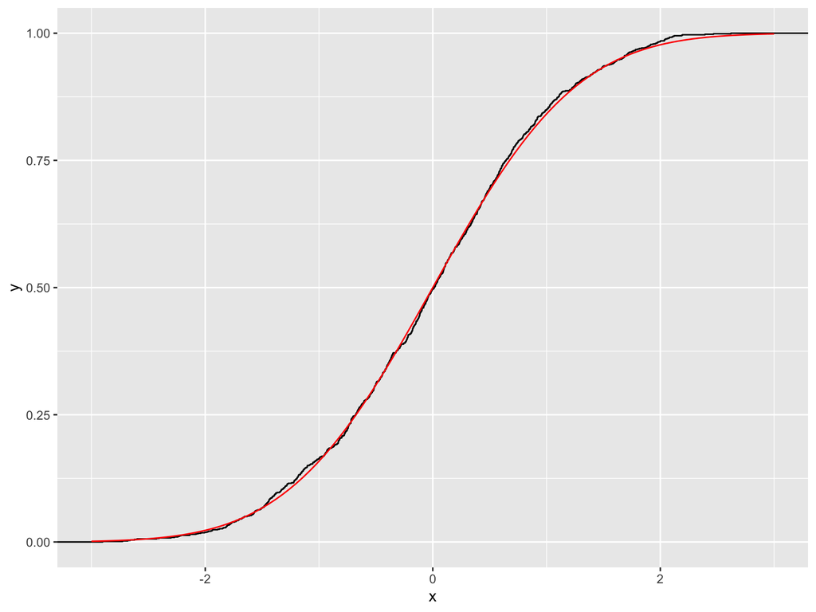

```r
library(ggplot2)
n <- 1000
df <- data.frame(x = c(rnorm(n, 0, 1)))
base <- ggplot(df, aes(x)) + stat_ecdf()
base + stat_function(fun = pnorm, colour = "red") + xlim(c(-3,3))
```

# Empirical process

Empirical distribution is close to the underlying distribution

- Glivenko-Cantelli Theorem
  $$\sup_x | F_n(x) - F(x)| \rightarrow 0$$
- Dvoretzky-Kiefer-Wolfowitz inequality, for any $\varepsilon > 0$
  $$P(\sup_x | F_n(x) - F(x)| > \varepsilon) \le 2\exp(-2n\varepsilon^2)$$

# Variance of the “median estimator”, Bootstrapping method

Instead of drawing samples from the underlying distribution $F \sim N(\mu, \sigma^2)$, we draw from the empirical distribution $F_n$

# How to sample from the empirical distribution?

- **Drawing $X_1^*, \ldots, X_n^*$ from $F_n$ is equivalent to draw $n$ observations, with replacement from the original data $\{X_1, \ldots, X_n\}$**.
- Therefore, Bootstrapping sampling is also described as resampling data.
- For $b = 1, \ldots, B$
  - draw $X^{b}_1, \ldots, X^{b}_n \sim \{ X_1, \ldots, X_n \}$ with replacement.
  - Compute $T^{(b)}_n = median_{i=1}^n(X^{b}_i)$
- $\bar{T}_n = \frac{1}{B} \sum_{b=1}^B T^{(b)}_n$
- $\hat{V}_{F_n} (T_n) = \frac{1}{B-1} \sum_{b=1}^B \{T^{(b)}_n - \bar{T}_n \}^2$

# Variance of “median estimator”, Bootstrapping method

```r
mu <- 1
sigma <- 1
n <- 100
set.seed(32611)
X <- rnorm(n, mu, sigma)
B <- 1000
Ts <- numeric(B)

for(b in 1:B){
  set.seed(b)
  ax <- sample(X, replace = T)
  Ts[b] <- median(ax)
}

varTest <- var(Ts)
print(varTest)
```

```
## [1] 0.02598333
```

# Bootstrapping Variance Estimator

1. Draw a bootstrap sample $X_1^*, \ldots, X_n^* \sim F_n$, where $F_n$ is the emperical CDF. Compute ${T^*}_n = g(X_1^*, \ldots, X_n^*)$.
2. Repeat the previous step $B$ times, yielding estimators ${T^*}_n^{(1)}, \ldots, {T^*}_n^{(B)}$.
3. Compute
   $$\hat{Var}_{F_n}({T}_n) = \frac{1}{B-1}\sum_{b=1}^B ({T^*}_n^{(b)} - \bar{T}^*)^2,$$
   where $\bar{T}^* = \frac{1}{B}\sum_{b=1}^B {T^*}_n^{(b)}$
4. Output $\hat{Var}_{F_n}({T}_n)$ as the bootstrap variance of ${T}_n$.

# Why Bootstrapping variance works?

- $T_n = g(X_1, \ldots, X_n)$
- $mean_F(T_n) = \int g(X_1, \ldots, X_n) f(X) dX = \int g(X_1, \ldots, X_n) dF$
- $Var_F(T_n) = \int (g(X_1, \ldots, X_n) - mean_F(T_n))^2 dF$

Since in general, we don’t know distribution $F$, we will calculate using the empirical CDF $F_n$.

- $Var_{F_n}(T_n) = \int (g(X_1, \ldots, X_n) - mean_{F_n}(T_n))^2 dF_n$
- Finally, we used bootstrap variance $\hat{Var}_{F_n}(T_n)$ to estimate $Var_{F_n}(T_n)$.

To summarize:

- Estimation error: $Var_F(T_n) - Var_{F_n}(T_n) = O_p(1/\sqrt{n})$
- Simulation error: $Var_{F_n}(T_n) - \hat{Var}_{F_n}(T_n) = O_p(1/\sqrt{B})$

# The parametric Bootstrapping (Variance of “median estimator”)

- Calculate $\hat{\mu} = \arg\max L(\mu;X_1^n)$, $\sigma$ is known.
- For $b = 1, \ldots, B$
  - draw $X^{b}_1, \ldots, X^{b}_n \sim N(\hat{\mu},\sigma^2)$ ($\hat{F}$)
  - Compute $\hat{T}^{(b)}_n = median_{i=1}^n(X^{b}_i)$
- $\bar{\hat{T}}_n = \frac{1}{B} \sum_{b=1}^B \hat{T}^{(b)}_n$
- $\hat{V}_F (T_n) = \frac{1}{B-1} \sum_{b=1}^B \{\hat{T}^{(b)}_n - \bar{\hat{T}}_n \}^2$

# The parametric Bootstrapping (Variance of “median estimator”)

```r
mu <- 1
sigma <- 1
n <- 100
set.seed(32611)
X <- rnorm(n, mu, sigma)
muhat <- mean(X)
B <- 1000
Ts <- numeric(B)

for(b in 1:B){
  set.seed(b)
  ax <- rnorm(n,muhat,sigma)
  Ts[b] <- median(ax)
}

varTest <- var(Ts)
print(varTest)
```

```
## [1] 0.014573
```

# Comparison study

- $X_1, \ldots, X_n \sim POI(\lambda)$ ($\lambda = 5$), while we only observe the data $X_1, \ldots, X_n$ and know data is from Poisson.
- $n = 100$
- $T_n = (\frac{1}{n}\sum_{i=1}^nX_i)^2$
- What is the variance of $T_n$?
- Methods:
  - delta method
  - non-parametric Bootstrapping
  - parametric Bootstrapping
  - simulation (requires knowning the underlying parameter $\lambda$)

# Delta method

- $\hat{\lambda} = \bar{X}$
- $var(\bar{X}) = \frac{\lambda}{n}$
- $var(T_n) = var(\bar{X}^2) = (2 \lambda)^2 \times var(\bar{X}) = \frac{4\lambda^3}{n}$
- $\hat{var}_F(T_n) = \frac{4\hat{\lambda}^3}{n} = \frac{4\bar{X}^3}{n}$

```r
lambda <- 5
n <- 100
set.seed(32611)
X <- rpois(n, lambda)
var_hat1 <- 4*mean(X)^3/n
print(var_hat1)
```

```
## [1] 4.97006
```

# Bootstrapping (non-parametric)

```r
lambda <- 5
n <- 100
set.seed(32611)
X <- rpois(n, lambda)
B <- 1000
TB <- numeric(B)
for(b in 1:B){
  set.seed(b)
  aX <- sample(X,n,replace = T)
  TB[b] <- (mean(aX))^2
}
var_hat2 <- var(TB)
print(var_hat2)
```

```
## [1] 4.44549
```

# Parametric Bootstrapping

```r
lambda <- 5
n <- 100
set.seed(32611)
X <- rpois(n, lambda)
lambdaHat <- mean(X)
B <- 1000
TB <- numeric(B)
for(b in 1:B){
  set.seed(b)
  aX <- rpois(n, lambdaHat)
  TB[b] <- (mean(aX))^2
}
var_hat3 <- var(TB)
print(var_hat3)
```

```
## [1] 5.261807
```

# Bootstrapping using R package

```r
library(boot)
myMean <- function(data, indices){
  d <- data[indices]
  mean(d)^2
}

## non parametric bootstrap
set.seed(32611)
boot_nonpara <- boot(data=X, statistic = myMean, R = B)
var(boot_nonpara$t)
```

```
##          [,1]
## [1,] 4.495394
```

```r
## parametric bootstrap
genPois <- function(data, lambda){
  rpois(length(data), lambda)
}
boot_para <- boot(data=X, statistic = myMean, R = B, sim="parametric", ran.gen = genPois, mle = mean(X))
var(boot_para$t)
```

```
##          [,1]
## [1,] 5.199379
```

# Simulation

```r
lambda <- 5
n <- 100
B <- 1000
Ts <- numeric(B)
for(b in 1:B){
  set.seed(b)
  aX <- rpois(n, lambda)
  Ts[b] <- (mean(aX))^2
}
print(var(Ts))
```

```
## [1] 5.28793
```

# Summary

- Assume $\sigma$ is known.
- For $b = 1, \ldots, B$
  - draw $X^{b}_1, \ldots, X^{b}_n$ from
    - Simulation: $N(\mu,\sigma^2)$
    - Non-parametric bootstrapping: $X^{b}_1, \ldots, X^{b}_n \sim \{ X_1, \ldots, X_n \}$ with replacement.
    - Parametric bootstrapping: $N(\hat{\mu},\sigma^2)$
  - Compute $T^{(b)}_n = median_{i=1}^n(X^{b}_i)$
- $\bar{T}_n = \frac{1}{B} \sum_{b=1}^B T^{(b)}_n$
- $\hat{V}_{F_n} (T_n) = \frac{1}{B-1} \sum_{b=1}^B \{T^{(b)}_n - \bar{T}_n \}^2$

# Summary

- Goal: to estimate the variance of an estimator

| Method | Need simulation? | Need underlying parameter |
| --- | --- | --- |
| Delta method | N | N |
| Non-parametric bootstrapping | Y | N |
| Parametric bootstrapping | Y | N |
| Simulation | Y | Y |

# Comparison between Simulation and Non-parametric bootstrapping

- Simulation: Monte Carlo Simulation from underlying distribution.
- Non-parametric bootstrapping: Monte Carlo Simulation from the empirical distribution.

The rest of the percedures are the same

# Bootstrap confidence interval

- Percentiles
- normal approximation
- Pivotal Intervals

# Bootstrapping confidence interval via Percentiles

1. Draw a bootstrap sample $X_1^*, \ldots, X_n^* \sim F_n$. Compute ${T^*}_n = g(X_1^*, \ldots, X_n^*)$.
2. Repeat the previous step $B$ times, yielding estimators ${T^*}_n^{(1)}, \ldots, {T^*}_n^{(B)}$.
3. Rank ${T^*}_n^{(1)}, \ldots, {T^*}_n^{(B)}$ such that ${T^r}_n^{(1)} \le {T^r}_n^{(2)} \le \ldots \le {T^r}_n^{(B)}$

We can define 95% confidence interval using (if B = 10,000)
$$[{T^r}_n^{(250)}, {T^r}_n^{(9750)}]$$

# Calculate Bootstrapping confidence interval via Percentiles (1)

```r
lambda <- 5
n <- 100
set.seed(32611)
X <- rpois(n, lambda)
B <- 1000
TB <- numeric(B)
for(b in 1:B){
  set.seed(b)
  aX <- sample(X,n,replace = T)
  TB[b] <- (mean(aX))^2
}
quantile(TB, c(0.025, 0.975))
```

```
##     2.5%    97.5%
## 20.97411 29.16000
```

# Performance of Bootstrapping confidence interval via Percentiles (2)

- Underlying truth:

$$E(\bar{X}^2) = E(\bar{X})^2 + var(\bar{X}) = \lambda^2 + \lambda/n$$

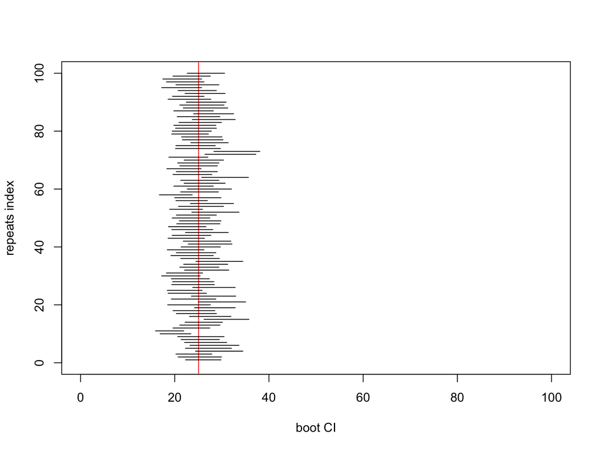

```r
lambda <- 5
n <- 100
truth <- lambda^2 + lambda/n
B <- 1000
Repeats <- 100

counts <- 0

plot(c(0,100),c(0,Repeats), type="n", xlab="boot CI", ylab="repeats index")
abline(v = truth, col=2)

for(r in 1:Repeats){
  set.seed(r)
  X <- rpois(n, lambda)
  TB <- numeric(B)
  for(b in 1:B){
    set.seed(b)
    aX <- sample(X,n,replace = T)
    TB[b] <- (mean(aX))^2
  }
  segments(quantile(TB, c(0.025)), r, quantile(TB, c(0.975)), r)
  if(quantile(TB, c(0.025)) < truth & truth < quantile(TB, c(0.975))){
    counts <- counts + 1
  }
}
```

```r
counts/Repeats
```

```
## [1] 0.93
```

# Calculation of Bootstrapping confidence interval via Percentiles (3)

- We can also obtain this Percentiles CI by boot package

```r
library(boot)
myMean <- function(data, indices){
  d <- data[indices] ## in this example, data is a vector
  mean(d)^2
}
boot_nonpara <- boot(data=X, statistic = myMean, R = B)
boot.ci(boot_nonpara, type="perc")
```

```
## BOOTSTRAP CONFIDENCE INTERVAL CALCULATIONS
## Based on 1000 bootstrap replicates
##
## CALL :
## boot.ci(boot.out = boot_nonpara, type = "perc")
##
## Intervals :
## Level     Percentile
## 95%   (22.56, 30.80 )
## Calculations and Intervals on Original Scale
```

# Normal approximation

- $Z_{0.025} = -1.96$
- $Z_{0.975} = 1.96$

Where $\hat{T}_n$ is the estimator from the original sample and $\hat{\sigma}_B$ is bootstrap se.

# Implementation for Normal approximation

```r
lambda <- 5
n <- 100
B <- 1000

set.seed(32611)
X <- rpois(n, lambda)
lambdaHat <- mean(X)
That <- lambdaHat^2
TB <- numeric(B)
for(b in 1:B){
  set.seed(b)
  aX <- sample(X,n,replace = T)
  TB[b] <- (mean(aX))^2
}
ci_l <- That - 1.96*sd(TB)
ci_u <- That + 1.96*sd(TB)

c(ci_l, ci_u)
```

```
## [1] 20.76757 29.03263
```

# Evaluation for Normal approximation

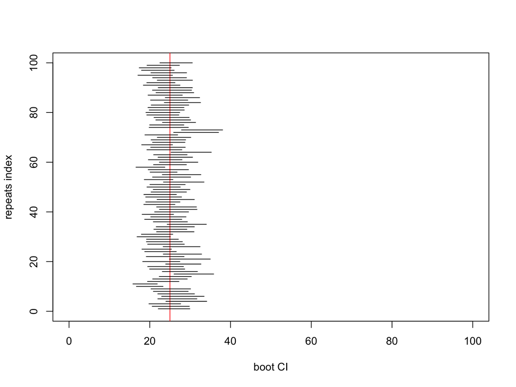

```r
lambda <- 5
n <- 100
truth <- lambda^2
B <- 1000
Repeats <- 100

counts <- 0

plot(c(0,100),c(0,Repeats), type="n", xlab="boot CI", ylab="repeats index")
abline(v = truth, col=2)

for(r in 1:Repeats){
  set.seed(r)
  X <- rpois(n, lambda)
  lambdaHat <- mean(X)
  That <- lambdaHat^2
  TB <- numeric(B)
  for(b in 1:B){
    set.seed(b)
    aX <- sample(X,n,replace = T)
    TB[b] <- (mean(aX))^2
  }
  ci_l <- That - 1.96*sd(TB)
  ci_u <- That + 1.96*sd(TB)
  segments(ci_l, r, ci_u, r)
  if(ci_l < truth & truth < ci_u){
    counts <- counts + 1
  }
}
```

```r
counts/Repeats
```

```
## [1] 0.93
```

# Bootstrapping confidence interval via Pivotal Intervals

- Won’t be covered this year.
- If you are interested in this, checkout previous lecture notes https://caleb-huo.github.io/teaching/2017FALL/lectures/week11_bootstrapAndPermutation/bootstrap/bootstrap.html

# Summary Bootstrapping confidence interval

| Precedure | Theoritical guarantee | Fast | R package Boot? |
| --- | --- | --- | --- |
| Percentiles | No | Yes | Yes |
| Pivotal Intervals | Yes | No | Yes |
| Pivotal Intervals (simplified, no se) | Yes | Yes | No |
| normal approximation | Yes | Yes | Yes |

# HW, Large scale Bootstrapping exercise

- For the HAPMAP data on hiperGator.
- Calculate the sample contrivance matrix.
- what is the Bootstrapping variance of the largest eigen value.
- what is the Bootstrapping confidence interval of the largest eigen value.

# Reference

- http://www.stat.cmu.edu/~larry/=stat705/Lecture13.pdf
- http://users.stat.umn.edu/~helwig/notes/bootci-Notes.pdf